# Pediatric Hepatitis C Patient Outcomes in a Tertiary Academic Medical Center Utilizing an Integrated Specialty Pharmacy Model: Cascade of Care

# 1 Study Details

## 1.1 Background

FDA approvals of hepatitis C medications (Harvoni, Epclusa, and Mavyret) for the pediatric population <18 years of age began in April of 2017. HSSP worked with the pediatric hepatology clinic to assist with starting treatment for these patients. HSSP pharmacists worked with patients on swallowing tablets and pellets, the insurance approval process, education of medication, on treatment monitoring, and ensuring labs completed for sustained virologic response (SVR); otherwise known as cure.

## 1.2 Methods

Descriptive reports of cascade of care among a pediatric population with Hepatitis C

### 1.2.1 Inclusion Criteria

- Patients <18 years
- Patients seen by a pediatric hepatologist at the Pediatric Hepatology Clinic at the Monroe Carrell Jr. Children’s Hospital at Vanderbilt
- Clinic visits between January 2017 and September 2022.

## 1.3 Outcomes

**Primary outcome:** Rate of achievement of each individual stage of the cascade of care (CoC) following evaluation (clinic evaluation, specialty pharmacy referral, successful practice administration, medication approval, medication initiation, medication completion, SVR completed, SVR achieved)

**Secondary outcomes:**

- Time from referral to the integrated specialty pharmacy to successful practice administration, to DAA approval, and to DAA initiation
- Reasons for gaps or delays in between steps of the cascade of care

# 2 Analysis

## 2.1 Demographics

### 2.1.1 All patients

```r
tab <- summaryM(age + sex + Race + height + weight + bmi +InsuranceType + referred_vsp + medication_initiation +time_to_initiation ~1,
                data=dat,continuous=5, na.include=T)
Hmisc::html(tab,
      caption="Patient Characteristics",long=T,exclude1=F)
```

| Patient Characteristics. | Patient Characteristics. N | Patient Characteristics. *N=119* |
| --- | --- | --- |
| Age | 119 | 3 5 8 |
| Gender | 119 |  |
| Female |  | 0.47 (56) |
| Male |  | 0.53 (63) |
| Race | 119 |  |
| Hispanic/Latino |  | 0.01 ( 1) |
| Black or African American |  | 0.01 ( 1) |
| White |  | 0.73 (87) |
| Unknown / Not Reported |  | 0.24 (28) |
| Other |  | 0.01 ( 1) |
| Arabic |  | 0.01 ( 1) |
| Height (cm) | 116 | 93.025 113.850 129.525 |
| Weight (kilograms) | 119 | 15.05 22.10 32.95 |
| BMI | 116 | 16.075 17.400 20.525 |
| InsuranceType | 119 |  |
| Medicaid |  | 0.85 (101) |
| Commercial |  | 0.12 ( 14) |
| None |  | 0.03 ( 4) |
| Was patient referred to HSSP? | 119 |  |
| Yes |  | 0.61 (73) |
| No |  | 0.39 (46) |
| Medication Initiation | 119 |  |
| Did not initate |  | 0.46 (55) |
| Initiated |  | 0.54 (64) |
| Time from HSSP referral to daa b start days | 64 | 22 43 129 |

*a* *b* *c* represent the lower quartile *a*, the median *b*, and the upper quartile *c* for continuous variables. *N* is the number of non-missing values. Numbers after proportions are frequencies.

### 2.1.2 All patients grouped by FDA age groups

```r
tab <- summaryM(age + sex + Race + height + weight + bmi +InsuranceType +  genotype+
                  referred_vsp + medication_initiation + Regimen + fibrosis_score  + viral_load_b +dosage_form + daa_lot +
                  treatment_naive  + ast_b + alt_b ~ age_group ,
                data=dat,continuous=5, na.include=T, overall=T)
Hmisc::html(tab,
      caption="Patient Characteristics",long=T,exclude1=F, digits=3)
```

| Patient Characteristics. | Patient Characteristics. N | Patient Characteristics. 0-5 years *N=61* | Patient Characteristics. 6-11 years *N=42* | Patient Characteristics. 12-17 years *N=16* | Patient Characteristics. Combined *N=119* |
| --- | --- | --- | --- | --- | --- |
| Age | 119 | 1.0 3.0 5.0 | 6.0 7.0 9.0 | 14.0 15.0 16.2 | 3.0 5.0 8.0 |
| Gender | 119 |  |  |  |  |
| Female |  | 0.30 (18) | 0.60 (25) | 0.81 (13) | 0.47 (56) |
| Male |  | 0.70 (43) | 0.40 (17) | 0.19 ( 3) | 0.53 (63) |
| Race | 119 |  |  |  |  |
| Hispanic/Latino |  | 0.00 ( 0) | 0.00 ( 0) | 0.06 ( 1) | 0.01 ( 1) |
| Black or African American |  | 0.02 ( 1) | 0.00 ( 0) | 0.00 ( 0) | 0.01 ( 1) |
| White |  | 0.70 (43) | 0.76 (32) | 0.75 (12) | 0.73 (87) |
| Unknown / Not Reported |  | 0.28 (17) | 0.24 (10) | 0.06 ( 1) | 0.24 (28) |
| Other |  | 0.00 ( 0) | 0.00 ( 0) | 0.06 ( 1) | 0.01 ( 1) |
| Arabic |  | 0.00 ( 0) | 0.00 ( 0) | 0.06 ( 1) | 0.01 ( 1) |
| Height (cm) | 116 | 76.2 94.0 106.6 | 118.3 125.3 134.9 | 148.8 157.0 162.1 | 93.0 113.8 129.5 |
| Weight (kilograms) | 119 | 9.8 15.1 18.9 | 24.7 27.5 33.4 | 49.8 58.5 74.0 | 15.1 22.1 33.0 |
| BMI | 116 | 15.6 16.6 17.8 | 16.6 17.6 20.5 | 20.3 22.8 26.6 | 16.1 17.4 20.5 |
| InsuranceType | 119 |  |  |  |  |
| Medicaid |  | 0.87 ( 53) | 0.83 ( 35) | 0.81 ( 13) | 0.85 (101) |
| Commercial |  | 0.08 ( 5) | 0.14 ( 6) | 0.19 ( 3) | 0.12 ( 14) |
| None |  | 0.05 ( 3) | 0.02 ( 1) | 0.00 ( 0) | 0.03 ( 4) |
| Genotype | 119 |  |  |  |  |
| Genotype 1 |  | 0.34 (21) | 0.57 (24) | 0.69 (11) | 0.47 (56) |
| Genotype 2 |  | 0.02 ( 1) | 0.05 ( 2) | 0.06 ( 1) | 0.03 ( 4) |
| Genotype 3 |  | 0.05 ( 3) | 0.19 ( 8) | 0.06 ( 1) | 0.10 (12) |
| Genotype 4 |  | 0.00 ( 0) | 0.00 ( 0) | 0.06 ( 1) | 0.01 ( 1) |
| NA |  | 0.59 (36) | 0.19 ( 8) | 0.12 ( 2) | 0.39 (46) |
| Was patient referred to HSSP? | 119 |  |  |  |  |
| Yes |  | 0.43 (26) | 0.79 (33) | 0.88 (14) | 0.61 (73) |
| No |  | 0.57 (35) | 0.21 ( 9) | 0.12 ( 2) | 0.39 (46) |
| Medication Initiation | 119 |  |  |  |  |
| Did not initate |  | 0.67 (41) | 0.24 (10) | 0.25 ( 4) | 0.46 (55) |
| Initiated |  | 0.33 (20) | 0.76 (32) | 0.75 (12) | 0.54 (64) |
| Regimen | 119 |  |  |  |  |
| Epclusa 200/50mg Pellets x 12 weeks |  | 0.02 ( 1) | 0.00 ( 0) | 0.00 ( 0) | 0.01 ( 1) |
| Epclusa 200/50mg Tablets x 12 weeks |  | 0.05 ( 3) | 0.17 ( 7) | 0.00 ( 0) | 0.08 (10) |
| Epclusa 400/100mg Pellets x 12 weeks |  | 0.00 ( 0) | 0.05 ( 2) | 0.00 ( 0) | 0.02 ( 2) |
| Epclusa 400/100mg Tablets x 12 weeks |  | 0.00 ( 0) | 0.10 ( 4) | 0.00 ( 0) | 0.03 ( 4) |
| Harvoni 33.75/150mg Pellets x 12 weeks |  | 0.05 ( 3) | 0.00 ( 0) | 0.00 ( 0) | 0.03 ( 3) |
| Harvoni 45/200mg Pellets x 12 weeks |  | 0.05 ( 3) | 0.02 ( 1) | 0.00 ( 0) | 0.03 ( 4) |
| Harvoni 45/200mg Tablets x 12 weeks |  | 0.18 (11) | 0.36 (15) | 0.00 ( 0) | 0.22 (26) |
| Harvoni 90/400mg Tablets x 12 weeks |  | 0.00 ( 0) | 0.07 ( 3) | 0.50 ( 8) | 0.09 (11) |
| Mavyret 300/120mg Tablets x 8 weeks |  | 0.00 ( 0) | 0.00 ( 0) | 0.25 ( 4) | 0.03 ( 4) |
| NA |  | 0.66 (40) | 0.24 (10) | 0.25 ( 4) | 0.45 (54) |
| Fibrosis Score | 119 |  |  |  |  |
| F0 |  | 0.05 ( 3) | 0.07 ( 3) | 0.25 ( 4) | 0.08 (10) |
| F1 |  | 0.00 ( 0) | 0.02 ( 1) | 0.12 ( 2) | 0.03 ( 3) |
| F4 |  | 0.00 ( 0) | 0.02 ( 1) | 0.00 ( 0) | 0.01 ( 1) |
| F2-3 |  | 0.00 ( 0) | 0.05 ( 2) | 0.00 ( 0) | 0.02 ( 2) |
| no score available and no cirrhosis |  | 0.34 (21) | 0.64 (27) | 0.50 ( 8) | 0.47 (56) |
| NA |  | 0.61 (37) | 0.19 ( 8) | 0.12 ( 2) | 0.39 (47) |
| Baseline Viral Load (IU/mL) | 74 | 230500 651144 2993814 | 432619 1396356 3242928 | 285110 554147 1661144 | 329576 826275 3083763 |
| Tablets or Pellets | 119 |  |  |  |  |
| Tablets |  | 0.23 (14) | 0.69 (29) | 0.75 (12) | 0.46 (55) |
| Pellets |  | 0.11 ( 7) | 0.07 ( 3) | 0.00 ( 0) | 0.08 (10) |
| NA |  | 0.66 (40) | 0.24 (10) | 0.25 ( 4) | 0.45 (54) |
| Length of DAA Regimen | 119 |  |  |  |  |
| 8 weeks |  | 0.00 ( 0) | 0.00 ( 0) | 0.25 ( 4) | 0.03 ( 4) |
| 12 weeks |  | 0.34 (21) | 0.76 (32) | 0.50 ( 8) | 0.51 (61) |
| NA |  | 0.66 (40) | 0.24 (10) | 0.25 ( 4) | 0.45 (54) |
| Treatment naïve | 119 |  |  |  |  |
| Yes |  | 0.43 (26) | 0.81 (34) | 0.88 (14) | 0.62 (74) |
| NA |  | 0.57 (35) | 0.19 ( 8) | 0.12 ( 2) | 0.38 (45) |
| AST (U/L) | 74 | 45.0 50.5 62.8 | 34.0 44.0 57.2 | 28.8 37.0 47.5 | 35.2 46.5 61.2 |
| ALT (U/L) | 74 | 39.0 51.5 79.0 | 34.2 49.0 65.0 | 29.2 48.0 64.2 | 33.2 49.5 74.2 |

*a* *b* *c* represent the lower quartile *a*, the median *b*, and the upper quartile *c* for continuous variables. *N* is the number of non-missing values. Numbers after proportions are frequencies.

## 2.2 Rate of achievment in each cascade of care

### 2.2.1 Completion of Cascade of Care

```r
dat$clinic_visit <- ymd(dat$clinic_visit)
dat$vsp_referral_date <- ymd(dat$vsp_referral_date)
dat$date_successful_practice <- ymd(dat$date_successful_practice)
dat$date_medication_approval <- ifelse(dat$pa_outcome == "Approved", dat$pa_outcome_date,
                                ifelse(dat$pa_outcome %in% c("Denied", "Partial approval") & dat$appeal_outcome == "Approved", dat$appeal_outcome_date, NA))
dat$date_medication_approval[dat$study_id %in% c(8, 3475)] <- dat$appeal_outcome_date[dat$study_id %in% c(8, 3475)]
dat$date_medication_approval[dat$study_id %in% c(3438)] <- dat$pa_outcome_date[dat$study_id %in% c(3438)]

#id 8, 3438, and 3475 were given approval but did not have appeal approved
dat$date_medication_approval <-  ymd(dat$date_medication_approval)
dat$daa_b_start_date <- ymd(dat$daa_b_start_date)
dat$end_date <- ymd(dat$end_date)
dat$svr_viral_load_date <- ymd(dat$svr_viral_load_date)
dat[dat$swallowing == "Yes" & !is.na(dat$swallowing), "date_successful_practice"] <- dat[dat$swallowing == "Yes"& !is.na(dat$swallowing), "vsp_referral_date"]
dat$`Complete Clinic Visit` <- ifelse(!is.na(dat$clinic_visit), "Yes" ,"No")
dat$`Complete VSP Referral` <- ifelse(!is.na(dat$vsp_referral_date), "Yes" ,"No")
dat$`Complete Successful Practice` <- ifelse(!is.na(dat$date_successful_practice), "Yes" ,"No")
dat$`Complete Medication Initiation` <- ifelse(!is.na(dat$daa_b_start_date), "Yes" ,"No")
dat$`Complete Medication End` <- ifelse(!is.na(dat$end_date), "Yes" ,"No")
dat$`Complete SVR Viral Load` <- ifelse(!is.na(dat$svr_viral_load_date), "Yes" ,"No")
dat$insurance_approval_date <- ifelse(dat$pa_outcome == "Approved", dat$pa_outcome_date,
                               ifelse((dat$pa_outcome == "Partial approval" |
                                         dat$pa_outcome == "Denied") &
                                        (dat$appeal_outcome == "Approved"|
                                        dat$appeal_outcome == "Cancelled"), dat$appeal_outcome_date, NA))
dat$insurance_approval_date[dat$study_id == 3438] <- "2020-2-21"
dat$insurance_approval_date[dat$study_id == 4006] <- "2020-05-12"
#dat %>% filter(study_id %in%  c(4006,8, 3438, 3475)) %>% select(1,pa_outcome, pa_required, pa_outcome_date, appeal_outcome, appeal_outcome_date, insurance_approval_date)
dat$"Complete Insurance Approval" <- ifelse(!is.na(dat$insurance_approval_date), "Yes", "No")
dat$"Complete Achieved SVR" <- ifelse(dat$svr_achieved == "Yes", "Yes", "No")
dat$`Complete Achieved SVR`[is.na(dat$`Complete Achieved SVR`)] <- "No"
tab <- summaryM(`Complete Clinic Visit`+
                 `Complete VSP Referral` +`Complete Successful Practice`+ `Complete Insurance Approval`+
                  `Complete Medication Initiation` +`Complete Medication End`+
                  `Complete SVR Viral Load`+`Complete Achieved SVR`~1,
                data=dat,continuous=5, na.include=T)
Hmisc::html(tab,
      caption="Completion rates of CoC",long=T,exclude1=F)
```

| Completion rates of CoC. | Completion rates of CoC. *N=119* |
| --- | --- |
| Complete Clinic Visit |  |
| Yes | 1 (119) |
| NO | 0 ( 0) |
| Complete VSP Referral |  |
| No | 0.39 (46) |
| Yes | 0.61 (73) |
| Complete Successful Practice |  |
| No | 0.42 (50) |
| Yes | 0.58 (69) |
| Complete Insurance Approval |  |
| No | 0.44 (52) |
| Yes | 0.56 (67) |
| Complete Medication Initiation |  |
| No | 0.46 (55) |
| Yes | 0.54 (64) |
| Complete Medication End |  |
| No | 0.46 (55) |
| Yes | 0.54 (64) |
| Complete SVR Viral Load |  |
| No | 0.49 (58) |
| Yes | 0.51 (61) |
| Complete Achieved SVR |  |
| No | 0.5 (60) |
| Yes | 0.5 (59) |

Numbers after proportions are frequencies.

### 2.2.2 Modeling time from referral to medication initiation

- The model outcome is time to initiation from VSP referral in days
- Only the 64 patients with a medication initiation are included in the model
- An ordinal logistic regression model was fit due to the strong skew of the outcome

#### 2.2.2.1 Distribution of the outcome

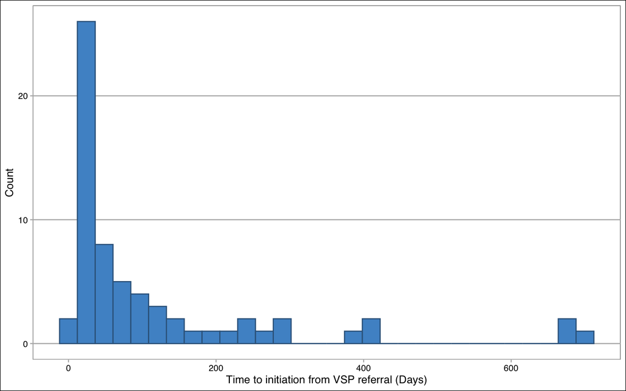

```r
ggplot(dat=dat, aes(x=time_to_initiation)) +
  geom_histogram(color="Steelblue4", fill="steelblue3") +
  xlab("Time to initiation from VSP referral (Days)") + ylab("Count") +
  ggthemes::theme_calc()
```

#### 2.2.2.2 Model Summary

##### 2.2.2.2.1 Without vsp availability

```r
mod_dat <- dat[!is.na(dat$daa_b_start_date),]
mod_dat$time_to_initiation <- as.numeric(ymd(mod_dat$daa_b_start_date)  - ymd(mod_dat$vsp_referral_date))
mod_dat$pa_outcome <- droplevels(mod_dat$pa_outcome)
dd <- datadist(mod_dat %>% select(time_to_initiation,swallowing,vsp_available,pa_outcome))
options(datadist='dd')
fit <- orm(time_to_initiation~swallowing+pa_outcome, data=mod_dat)


res <- data.frame(Variable = grep('y>',names(coef(fit)),inv=T, v = T),
             lor = coef(fit)[grep('y>',names(coef(fit)),inv=T, v = T)],
             rse =sqrt(diag(vcov(fit)))[grep('y>',names(coef(fit)),inv=T, v = T)]) %>%
    mutate(lower = (lor - 1.96*rse), upper = (lor + 1.96*rse),
           `p-value` = format.pval( round(pchisq((lor/rse)^2,1, lower.tail = FALSE),4), digits = 3, eps = 0.001)) %>%
    mutate(`Log Odds Ratio` = lor, `Odds Ratio` = exp(lor), Lower = exp(lower), Upper = exp(upper)) %>%
    select(Variable, `Log Odds Ratio`,`Odds Ratio`, Lower, Upper, `p-value`)
res$Variable <- factor(res$Variable,
  levels=c("swallowing=No",
           "vsp_available=No",
           "pa_outcome=Denied",
           "pa_outcome=Partial approval"),
  labels=c("No",
           "Unavailable",
           "Denied",
           "Partially approved")
)
rownames(res) <- NULL
res %>%
  arrange(Variable) %>%
  kable(digits=2) %>%
  kable_paper("hover", full_width = F)%>%
  pack_rows("Swallowing (Reference: Yes)", 1, 1) %>%
  pack_rows("PA Outcome (Reference: Approved)", 2, 3) %>%
  add_header_above(c(" " = 3, "95% Confidence interval" = 2, " " = 1)) %>%
  kable_classic(full_width = F, html_font = "Cambria")
```

| Variable | Log Odds Ratio | Odds Ratio | 95% Confidence interval Lower | 95% Confidence interval Upper | p-value |
| --- | --- | --- | --- | --- | --- |
| **Swallowing (Reference: Yes)** |  |  |  |  |  |
| No | 1.36 | 3.89 | 1.58 | 9.61 | 0.003 |
| **PA Outcome (Reference: Approved)** |  |  |  |  |  |
| Denied | 0.88 | 2.42 | 0.77 | 7.64 | 0.132 |
| Partially approved | -0.32 | 0.72 | 0.22 | 2.35 | 0.591 |

```r
options(prType="html")
print(fit)
```

**Logistic (Proportional Odds) Ordinal Regression Model**

```
orm(formula = time_to_initiation ~ swallowing + pa_outcome, data = mod_dat)
```

|  | Model Likelihood Ratio Test | Discrimination Indexes | Rank Discrim. Indexes |
| --- | --- | --- | --- |
| Obs 64 | LR χ<sup>2</sup> 11.78 | *R*<sup>2</sup> 0.168 | ρ 0.422 |
| Distinct *Y* 50 | d.f. 3 | *R*<sup>2</sup><sub>3,64</sub> 0.128 |  |
| *Y*<sub>0.5</sub> 43 | Pr(>χ<sup>2</sup>) 0.0082 | *R*<sup>2</sup><sub>3,63.9</sub> 0.128 |  |
| max \|∂log *L*/∂β\| 6×10<sup>-5</sup> | Score χ<sup>2</sup> 11.92 | \|Pr(*Y* ≥ median)-½\| 0.166 |  |
|  | Pr(>χ<sup>2</sup>) 0.0077 |  |  |

|  | β | S.E. | Wald *Z* | Pr(>\|*Z*\|) |
| --- | --- | --- | --- | --- |
| swallowing=No | 1.3588 | 0.4615 | 2.94 | 0.0032 |
| pa_outcome=Denied | 0.8841 | 0.5862 | 1.51 | 0.1315 |
| pa_outcome=Partial approval | -0.3220 | 0.5995 | -0.54 | 0.5912 |

```r
print(anova(fit))
```

| Wald Statistics for `time_to_initiation` | Wald Statistics for `time_to_initiation` *χ<sup>2</sup>* | Wald Statistics for `time_to_initiation` d.f. | Wald Statistics for `time_to_initiation` *P* |
| --- | --- | --- | --- |
| swallowing | 8.67 | 1 | 0.0032 |
| pa_outcome | 2.98 | 2 | 0.2256 |
| TOTAL | 11.15 | 3 | 0.0109 |

##### 2.2.2.2.2 With vsp availability

```r
mod_dat <- dat[!is.na(dat$daa_b_start_date),]
mod_dat$time_to_initiation <- as.numeric(ymd(mod_dat$daa_b_start_date)  - ymd(mod_dat$vsp_referral_date))
mod_dat$pa_outcome <- droplevels(mod_dat$pa_outcome)
dd <- datadist(mod_dat %>% select(time_to_initiation,swallowing,vsp_available,pa_outcome))
options(datadist='dd')
fit <- orm(time_to_initiation~swallowing+vsp_available+pa_outcome, data=mod_dat)


res <- data.frame(Variable = grep('y>',names(coef(fit)),inv=T, v = T),
             lor = coef(fit)[grep('y>',names(coef(fit)),inv=T, v = T)],
             rse =sqrt(diag(vcov(fit)))[grep('y>',names(coef(fit)),inv=T, v = T)]) %>%
    mutate(lower = (lor - 1.96*rse), upper = (lor + 1.96*rse),
           `p-value` = format.pval( round(pchisq((lor/rse)^2,1, lower.tail = FALSE),4), digits = 3, eps = 0.001)) %>%
    mutate(`Log Odds Ratio` = lor, `Odds Ratio` = exp(lor), Lower = exp(lower), Upper = exp(upper)) %>%
    select(Variable, `Log Odds Ratio`,`Odds Ratio`, Lower, Upper, `p-value`)
res$Variable <- factor(res$Variable,
  levels=c("swallowing=No",
           "vsp_available=No",
           "pa_outcome=Denied",
           "pa_outcome=Partial approval"),
  labels=c("No",
           "Unavailable",
           "Denied",
           "Partially approved")
)
rownames(res) <- NULL
res %>%
  arrange(Variable) %>%
  kable(digits=2) %>%
  kable_paper("hover", full_width = F)%>%
  pack_rows("Swallowing (Reference: Yes)", 1, 1) %>%
  pack_rows("VSP Availability (Reference: Available)", 2, 2) %>%
  pack_rows("PA Outcome (Reference: Approved)", 3, 4) %>%
  add_header_above(c(" " = 3, "95% Confidence interval" = 2, " " = 1)) %>%
  kable_classic(full_width = F, html_font = "Cambria")
```

| Variable | Log Odds Ratio | Odds Ratio | 95% Confidence interval Lower | 95% Confidence interval Upper | p-value |
| --- | --- | --- | --- | --- | --- |
| **Swallowing (Reference: Yes)** |  |  |  |  |  |
| No | 1.37 | 3.94 | 1.56 | 9.98 | 0.004 |
| **VSP Availability (Reference: Available)** |  |  |  |  |  |
| Unavailable | 3.73 | 41.47 | 9.51 | 180.87 | <0.001 |
| **PA Outcome (Reference: Approved)** |  |  |  |  |  |
| Denied | 0.99 | 2.68 | 0.80 | 9.03 | 0.112 |
| Partially approved | 0.06 | 1.06 | 0.33 | 3.42 | 0.918 |

```r
options(prType="html")
print(fit)
```

**Logistic (Proportional Odds) Ordinal Regression Model**

```
orm(formula = time_to_initiation ~ swallowing + vsp_available +
    pa_outcome, data = mod_dat)
```

|  | Model Likelihood Ratio Test | Discrimination Indexes | Rank Discrim. Indexes |
| --- | --- | --- | --- |
| Obs 64 | LR χ<sup>2</sup> 42.33 | *R*<sup>2</sup> 0.484 | ρ 0.604 |
| Distinct *Y* 50 | d.f. 4 | *R*<sup>2</sup><sub>4,64</sub> 0.451 |  |
| *Y*<sub>0.5</sub> 43 | Pr(>χ<sup>2</sup>) <0.0001 | *R*<sup>2</sup><sub>4,63.9</sub> 0.451 |  |
| max \|∂log *L*/∂β\| 0.0005 | Score χ<sup>2</sup> 48.67 | \|Pr(*Y* ≥ median)-½\| 0.228 |  |
|  | Pr(>χ<sup>2</sup>) <0.0001 |  |  |

|  | β | S.E. | Wald *Z* | Pr(>\|*Z*\|) |
| --- | --- | --- | --- | --- |
| swallowing=No | 1.3721 | 0.4739 | 2.90 | 0.0038 |
| vsp_available=No | 3.7251 | 0.7514 | 4.96 | <0.0001 |
| pa_outcome=Denied | 0.9862 | 0.6197 | 1.59 | 0.1115 |
| pa_outcome=Partial approval | 0.0614 | 0.5958 | 0.10 | 0.9179 |

```r
print(anova(fit))
```

| Wald Statistics for `time_to_initiation` | Wald Statistics for `time_to_initiation` *χ<sup>2</sup>* | Wald Statistics for `time_to_initiation` d.f. | Wald Statistics for `time_to_initiation` *P* |
| --- | --- | --- | --- |
| swallowing | 8.38 | 1 | 0.0038 |
| vsp_available | 24.58 | 1 | <0.0001 |
| pa_outcome | 2.57 | 2 | 0.2760 |
| TOTAL | 33.42 | 4 | <0.0001 |

### 2.2.3 Median time between steps in cascade of care

```r
require(gtsummary)
dat$time_referral_admin <- dat$date_successful_practice - dat$vsp_referral_date
#View(dat %>% select(time_referall_admin, vsp_referral_date, date_successful_practice))
dat$insurance_approval_date <- ymd(dat$insurance_approval_date)
dat$time_admin_insurance <- dat$insurance_approval_date - dat$date_successful_practice
dat$time_insurance_initiation <- dat$daa_b_start_date - dat$insurance_approval_date
dat$time_referral_initiation <- dat$daa_b_start_date - dat$vsp_referral_date

#dat %>% select(1,date_successful_practice, insurance_approval_date,time_admin_insurance)
dat %>%
  select(time_referral_admin, time_admin_insurance, time_insurance_initiation, time_referral_initiation) %>%
  tbl_summary(type = all_continuous() ~ "continuous2",
    statistic = all_continuous() ~ c(
      "{N_nonmiss}",
      "{median} ({p25}, {p75})",
      "{min}, {max}"
    ))
```

| **Characteristic** | **N = 119** |
| --- | --- |
| time_referral_admin |  |
| N | 69 |
| Median (IQR) | 0 (0, 51) |
| Range | 0, 676 |
| Unknown | 50 |
| time_admin_insurance |  |
| N | 67 |
| Median (IQR) | 15 (5, 52) |
| Range | -14, 283 |
| Unknown | 52 |
| time_insurance_initiation |  |
| N | 64 |
| Median (IQR) | 11 (7, 20) |
| Range | -42, 59 |
| Unknown | 55 |
| time_referral_initiation |  |
| N | 64 |
| Median (IQR) | 43 (22, 129) |
| Range | 10, 710 |
| Unknown | 55 |

### 2.2.4 Visualization of Cascade of care

```r
label(dat$clinic_visit) <- NULL
label(dat$vsp_referral_date) <- NULL
label(dat$date_successful_practice) <- NULL
label(dat$daa_b_start_date) <- NULL
label(dat$end_date) <- NULL
label(dat$svr_viral_load_date) <- NULL
```

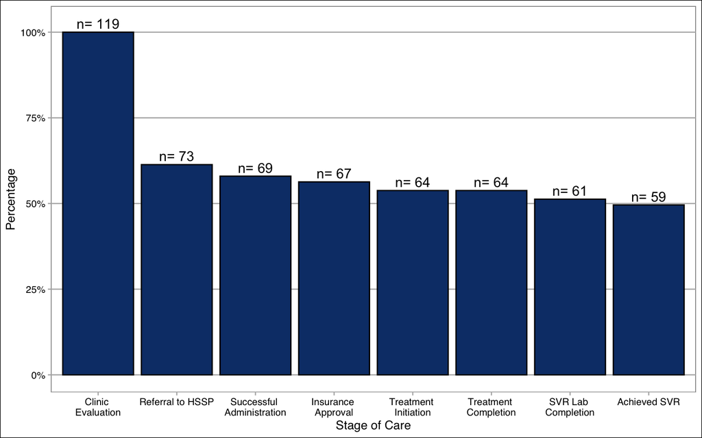

```r
stages <- c("Complete Clinic Visit",
                 "Complete VSP Referral","Complete Successful Practice", "Complete Insurance Approval",
                  "Complete Medication Initiation" ,"Complete Medication End",
                  "Complete SVR Viral Load", "Complete Achieved SVR")
plot_dat <- dat[,stages]
plot_dat <- sapply(plot_dat, function(x){ifelse(x == "Yes", 1, 0)})
stage_sum <- colSums(plot_dat)
plot_dat <- data.frame(Stage=names(stage_sum),
                       Count = unname(stage_sum))
plot_dat$Stage <- factor(plot_dat$Stage,
                         levels=c("Complete Clinic Visit",
                                  "Complete VSP Referral",
                                  "Complete Successful Practice",
                                  "Complete Insurance Approval",
                                  "Complete Medication Initiation" ,
                                  "Complete Medication End",
                                  "Complete SVR Viral Load",
                                  "Complete Achieved SVR"),
                         labels=c("Clinic Visit",
                                  "VSP Referral",
                                  "Successful Practice",
                                  "Insurance Approval",
                                  "Medication Initiation" ,
                                  "Medication End",
                                  "SVR Viral Load",
                                  "Achieved SVR"))
my.labels <- c(                   "Clinic \nEvaluation",
                                  "Referral to HSSP",
                                  "Successful \nAdministration",
                                  "Insurance \nApproval",
                                  "Treatment \nInitiation" ,
                                  "Treatment \nCompletion",
                                  "SVR Lab \nCompletion",
                                  "Achieved SVR")
plot_dat$Percentage <- plot_dat$Count/max(plot_dat$Count)
ggplot(plot_dat) +
  geom_bar(aes(y=Percentage, x=Stage), stat= "identity", alpha=1, color="black", fill="#0C3D77") +
  scale_y_continuous(labels = scales::percent_format(accuracy = 1)) +
  scale_x_discrete(labels= my.labels)+
  xlab("Stage of Care") +
  geom_text(aes(label=paste0("n= ",Count),x=Stage, y=Percentage+0.025), size=4) +
  #ylim(c(0,1.10)) +
  ggthemes::theme_calc()
```

```r
ggsave("COC_overall.png", dpi=300)

#ix <- which(dat$`Complete Medication Initiation` == "Yes" & dat$`Complete Insurance Approval` == "No")
#id <- dat$study_id[ix]
#dat %>% filter(study_id %in% id) %>% select(study_id ,pa_outcome, appeal_outcome, pa_outcome_date, appeal_outcome_date, insurance_approval_date, daa_b_start_date) %>% View()
```

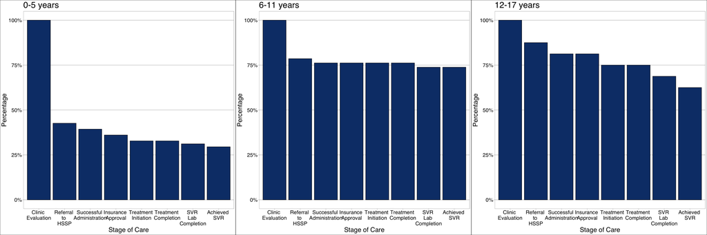

```r
stages <- c("Complete Clinic Visit",
                                  "Complete VSP Referral",
                                  "Complete Successful Practice",
                                  "Complete Insurance Approval",
                                  "Complete Medication Initiation" ,
                                  "Complete Medication End",
                                  "Complete SVR Viral Load",
                                  "Complete Achieved SVR")


####################### 0-5

plot_dat <- dat[dat$age_group == "0-5 years",stages]
plot_dat <- sapply(plot_dat, function(x){ifelse(x == "Yes", 1, 0)})
stage_sum <- colSums(plot_dat)
plot_dat <- data.frame(Stage=names(stage_sum),
                       Count = unname(stage_sum))
plot_dat$Percentage <- plot_dat$Count/max(plot_dat$Count)

plot_dat$Stage <- factor(plot_dat$Stage,
                         levels=c("Complete Clinic Visit",
                                  "Complete VSP Referral",
                                  "Complete Successful Practice",
                                  "Complete Insurance Approval",
                                  "Complete Medication Initiation" ,
                                  "Complete Medication End",
                                  "Complete SVR Viral Load",
                                  "Complete Achieved SVR"),
                         labels=c("Clinic Visit",
                                  "VSP Referral",
                                  "Successful Practice",
                                  "Insurance Approval",
                                  "Medication Initiation" ,
                                  "Medication End",
                                  "SVR Viral Load",
                                  "Achieved SVR"))
plot_dat1 <- plot_dat
#######################
####################### 6-11

plot_dat <- dat[dat$age_group == "6-11 years",stages]
plot_dat <- sapply(plot_dat, function(x){ifelse(x == "Yes", 1, 0)})
stage_sum <- colSums(plot_dat)
plot_dat <- data.frame(Stage=names(stage_sum),
                       Count = unname(stage_sum))
plot_dat$Percentage <- plot_dat$Count/max(plot_dat$Count)

plot_dat$Stage <- factor(plot_dat$Stage,
                         levels=c("Complete Clinic Visit",
                                  "Complete VSP Referral",
                                  "Complete Successful Practice",
                                  "Complete Insurance Approval",
                                  "Complete Medication Initiation" ,
                                  "Complete Medication End",
                                  "Complete SVR Viral Load",
                                  "Complete Achieved SVR"),
                         labels=c("Clinic Visit",
                                  "VSP Referral",
                                  "Successful Practice",
                                  "Insurance Approval",
                                  "Medication Initiation" ,
                                  "Medication End",
                                  "SVR Viral Load",
                                  "Achieved SVR"))
plot_dat2 <- plot_dat
#######################
####################### 12-17

plot_dat <- dat[dat$age_group == "12-17 years",stages]
plot_dat <- sapply(plot_dat, function(x){ifelse(x == "Yes", 1, 0)})
stage_sum <- colSums(plot_dat)
plot_dat <- data.frame(Stage=names(stage_sum),
                       Count = unname(stage_sum))
plot_dat$Percentage <- plot_dat$Count/max(plot_dat$Count)

plot_dat$Stage <- factor(plot_dat$Stage,
                         levels=c("Complete Clinic Visit",
                                  "Complete VSP Referral",
                                  "Complete Successful Practice",
                                  "Complete Insurance Approval",
                                  "Complete Medication Initiation" ,
                                  "Complete Medication End",
                                  "Complete SVR Viral Load",
                                  "Complete Achieved SVR"),
                         labels=c("Clinic Visit",
                                  "VSP Referral",
                                  "Successful Practice",
                                  "Insurance Approval",
                                  "Medication Initiation" ,
                                  "Medication End",
                                  "SVR Viral Load",
                                  "Achieved SVR"))
plot_dat3 <- plot_dat
#######################
my.labels <- c(                   "Clinic \nEvaluation",
                                  "Referral \nto \nHSSP",
                                  "Successful \nAdministration",
                                  "Insurance \nApproval",
                                  "Treatment \nInitiation" ,
                                  "Treatment \nCompletion",
                                  "SVR \nLab \nCompletion",
                                  "Achieved \nSVR")


g1 <- ggplot(plot_dat1) +
  geom_bar(aes(y=Percentage, x=Stage), stat= "identity",
           alpha=1, color="black",  fill="#0C3D77") +
  scale_x_discrete(labels= my.labels)+
  xlab("Stage of Care") +
    ggtitle("0-5 years")+
  scale_y_continuous(labels = scales::percent_format(accuracy = 1)) +

  ggthemes::theme_calc()+
 theme(text = element_text(size=20))

g2 <- ggplot(plot_dat2) +
  geom_bar(aes(y=Percentage, x=Stage), stat= "identity",
           alpha=1, color="black",  fill="#0C3D77") +
  scale_x_discrete(labels= my.labels)+
  xlab("Stage of Care") +
    ggtitle("6-11 years")+
  scale_y_continuous(labels = scales::percent_format(accuracy = 1)) +

  ggthemes::theme_calc()+
  theme(text = element_text(size=20))

g3 <- ggplot(plot_dat3) +
  geom_bar(aes(y=Percentage, x=Stage), stat= "identity",
           alpha=1, color="black",  fill="#0C3D77") +
  scale_y_continuous(labels = scales::percent_format(accuracy = 1)) +
  scale_x_discrete(labels= my.labels)+
  xlab("Stage of Care") +
  ggtitle("12-17 years")+
    #ylim(c(0,1))+

  ggthemes::theme_calc()+
  theme(text = element_text(size=20))
        #axis.text.x = element_text(angle=35, hjust=0.5))
cowplot::plot_grid(g1,g2,g3, cols=3)
```

```r
d <- 2.6
ggsave("COC_age.png", dpi=100, width=12*d, height=4*d, limitsize=F)
```

### 2.2.5 Referral information

```r
tab <- summaryM(referred_vsp + vsp_not_referred + start +
                  reason_for_not_start~1,
                data=dat,continuous=5, na.include=T)
Hmisc::html(tab,
      caption="Referral Information",long=T,exclude1=F)
```

| Referral Information. | Referral Information. *N=119* |
| --- | --- |
| Was patient referred to HSSP? |  |
| Yes | 0.61 (73) |
| No | 0.39 (46) |
| Why was patient not referred to VSP? |  |
| Lost to follow-up in clinic | 0.18 (22) |
| Will be followed by local provider | 0.02 ( 2) |
| Enrolled in HCV study | 0.03 ( 3) |
| HCV RNA negative x2 readings | 0.07 ( 8) |
| HCV Ab- after 18 months | 0.05 ( 6) |
| < 3 yo, will continue to follow until DAA is appropriate if applicable | 0.02 ( 2) |
| < 18 months, will continue to follow to see if HCV RNA+ after 18 months of age | 0.02 ( 2) |
| Prescriber monitoring swallowing (not yet sent to VIP and not able to swallow) | 0.01 ( 1) |
| NA | 0.61 (73) |
| Did Patient Start Therapy at VUMC? |  |
| Yes | 0.54 (64) |
| No | 0.08 ( 9) |
| NA | 0.39 (46) |
| Reason Not Started |  |
| Patient unable to administer prescribed dosage form | 0.03 ( 4) |
| Patient lost to follow-up | 0.03 ( 3) |
| Other | 0.01 ( 1) |
| Started treatment with outside provider and will be followed at OSF | 0.01 ( 1) |
| NA | 0.92 (110) |

Numbers after proportions are frequencies.